# Usando el GBM

Gibrán Leonardo Chávez González

# Paquetes necesarios

```r
library(quantmod)
library(moments)
library(tseries)

set.seed(456)
```

# Descargar datos reales

```r
ticker <- 'GFNORTEO.MX'

getSymbols(ticker, scr='yahoo', from='2015-01-01')
```

```
## [1] "GFNORTEO.MX"
```

```r
precio <- na.omit(Ad(get(ticker)))
```

# Precio, log del precio y rendimientos

```r
log_precio <- log(precio)

simple_rend <- dailyReturn(precio, type='arithmetic')

log_rend <- dailyReturn(precio, type='log')

head(cbind(simple_rend, log_rend, log_precio))
```

```
##            daily.returns daily.returns.1 GFNORTEO.MX.Adjusted
## 2015-01-02   0.000000000     0.000000000             3.727426
## 2015-01-05  -0.028288806    -0.028696645             3.698730
## 2015-01-06  -0.009660650    -0.009707616             3.689022
## 2015-01-07   0.021619099     0.021388720             3.710411
## 2015-01-08   0.015096257     0.014983443             3.725394
## 2015-01-09  -0.008516401    -0.008552873             3.716841
```

$$\text{Log Rend} = ln(\frac{S_T}{S_0})$$

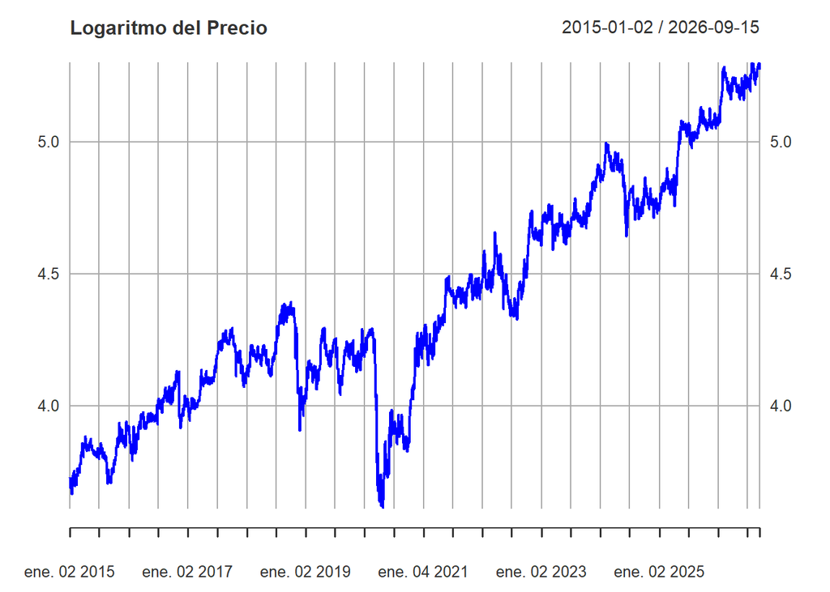

```r
plot(
  log_precio, # Proceso estocástico
  main='Logaritmo del Precio',
  col='blue'
)
```

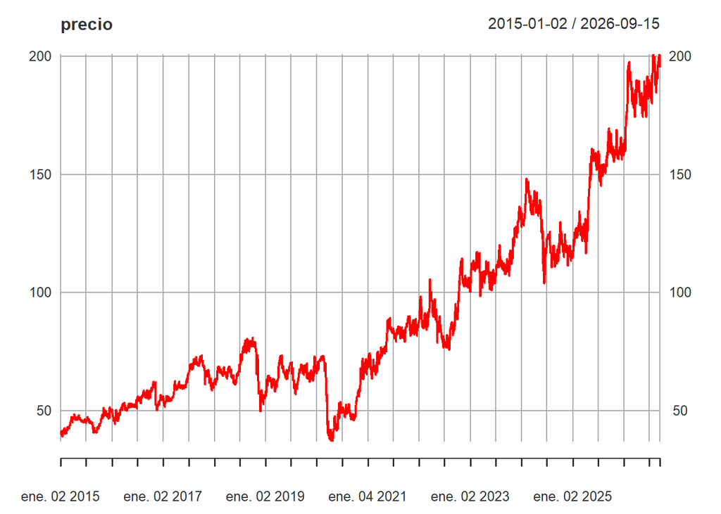

```r
plot(
  precio,
  main='precio',
  col='red'
)
```

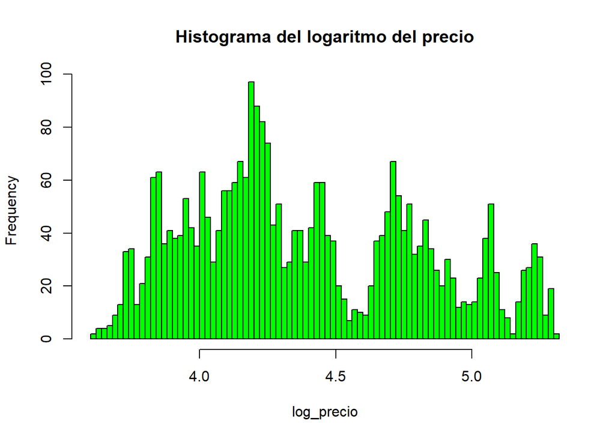

```r
hist(
  log_precio,
  n=100,
  main='Histograma del logaritmo del precio',
  col='green'
)
```

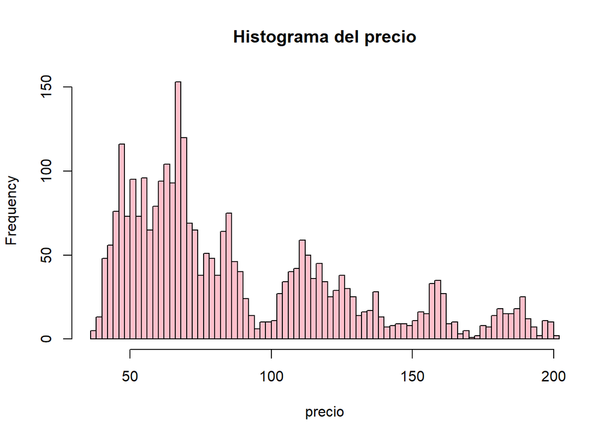

```r
hist(
  precio,
  n=100,
  main='Histograma del precio',
  col='pink'
)
```

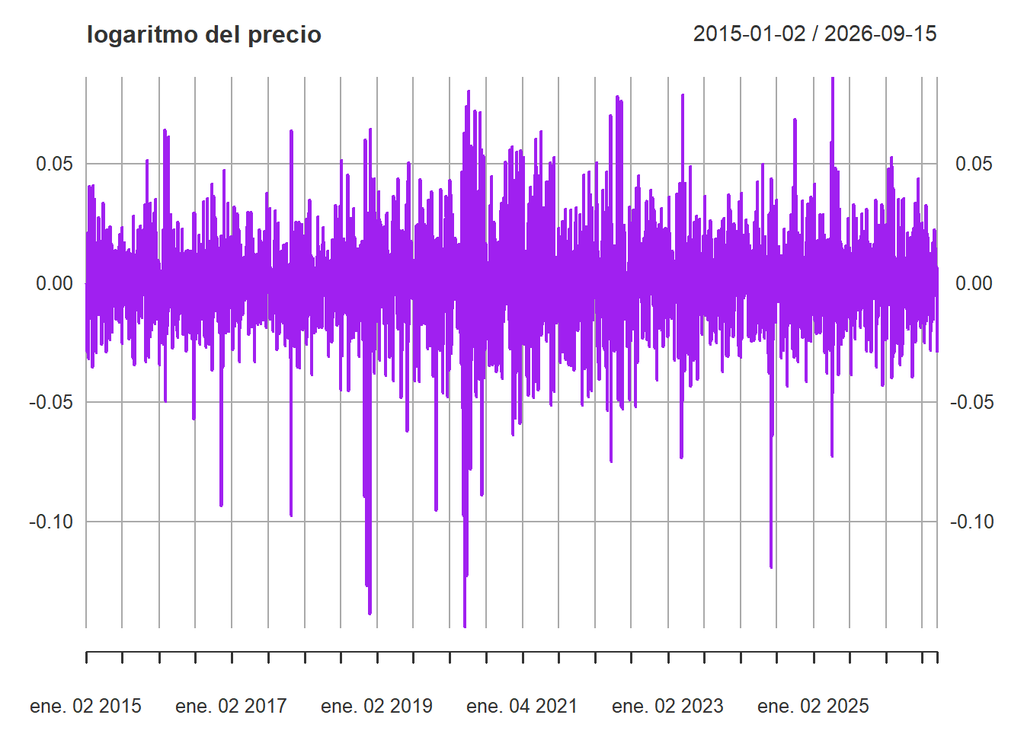

```r
plot(
  log_rend,
  n=100,
  main='logaritmo del precio',
  col='purple'
)
```

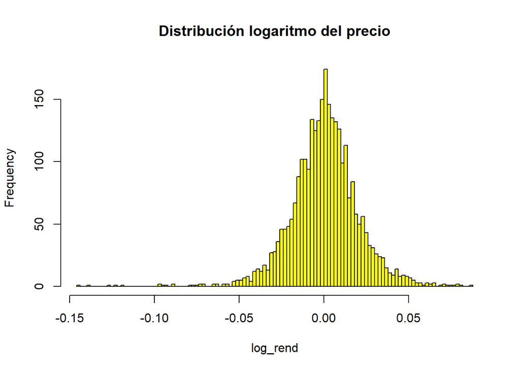

```r
hist(
  log_rend,
  n=100,
  main='Distribución logaritmo del precio',
  col='yellow'
)
```

# Media y Volatilidad diaria

$$R = \frac{dS_t}{S_t}$$

$$r = ln\frac{S_t}{S_t}$$

$$dS_t = S_t \mu d_t + S_t \sigma dW_t$$

$$\text{Log Rend} = ln(\frac{S_T}{S_0}) = (\mu - \frac{1}{2}\sigma^2)T +
\sigma \sqrt{T}Z$$
$$ln(S_T) = ln(S_0) + (\mu - \frac{1}{2}\sigma^2)T + \sigma \sqrt{T}Z$$

```r
r <- mean(log_rend)
R <- mean(simple_rend)
sigma_log <- sd(log_rend)

mean_log <- r

sigma_log
```

```
## [1] 0.02046529
```

```r
mean_log
```

```
## [1] 0.0005255395
```

La media del rendimiento logarítmico es casi cero. ¿Podemos decir que es estadísticamente igual a cero?

$$H_0: \mu_r = 0$$

$$H_1: \mu_r \neq 0$$

```r
t.test(
  as.numeric(log_rend),
  mu=0,
  alternative = 'two.sided'
)
```

```
##
##  One Sample t-test
##
## data:  as.numeric(log_rend)
## t = 1.3929, df = 2941, p-value = 0.1638
## alternative hypothesis: true mean is not equal to 0
## 95 percent confidence interval:
##  -0.0002142758  0.0012653548
## sample estimates:
##    mean of x
## 0.0005255395
```

# ¿Formalmente los rendimientos son normales?

$$H_0: \text{Los datos son normales}$$

$$H_1: \text{Los datos no son normales}$$

```r
jarque.bera.test(log_rend)
```

```
##
##  Jarque Bera Test
##
## data:  log_rend
## X-squared = 2484.6, df = 2, p-value < 2.2e-16
```

Rechazamos $H_0$, entonces los datos de manera formal no siguen un comportamiento de una distribución normal. Esto se puede ber por el sesgo y la curtósis.

```r
kurtosis(log_rend)
```

```
## daily.returns
##      7.387347
```

```r
skewness(log_rend)
```

```
## daily.returns
##    -0.5048386
```

# ¿Qué estima `mean(log_rend)`?

Aproximadamente estima el valor de:

$$E[r_{\Delta t}] \approx (\mu - \frac{1}{2}\sigma^2)\Delta t$$

# ¿Cómo podemos tener una medida de la volatilidad anual?

```r
dias_cot <- 252

sigma_anual <- sigma_log * sqrt(dias_cot)
sigma_anual
```

```
## [1] 0.3248763
```

```r
sigma_log
```

```
## [1] 0.02046529
```

Recordemos que $\sigma^2$ es lineal en el tiempo, sin embargo, $\sigma$ no lo es, por lo cual para anualizar hay que multiplicar por $\sqrt{252}$.

$$\sigma_{anual} = \sigma_{diaria} \sqrt{252}$$

# ¿Por qué por la raíz del tiempo y no solo por el tiempo?

Porque la varianza incrementa de forma más o menos proporcional al tiempo, pero la desviación estándar no.

# Estimar $\mu$

Recrodemos que del GBM, tenemos

$$E[r_{\Delta t}] \approx (\mu_a - \frac{1}{2}\sigma_a^2)\Delta t$$

Si todo está en términos diarios:

$$\Delta t = \frac{1}{252}$$
Despejando:

$$r_{diaria} \approx (\mu_a - \frac{1}{2}\sigma_a^2) \frac{1}{252}$$

$$252r_{diaria} \approx \mu_a - \frac{1}{2}\sigma_a^2$$

$$\mu_a \approx 252r_{diaria} + \frac{1}{2}\sigma_a^2$$

```r
mu_log_anual <- dias_cot * mean_log
mu_log_anual
```

```
## [1] 0.132436
```

```r
mu_gbm_anual <- mu_log_anual + 0.5 * sigma_anual^2
mu_gbm_anual
```

```
## [1] 0.1852083
```

# ¿Por qué sumamos $\frac{1}{2}\sigma_a^2$?

Porque cuando tenemos el valor esperado de la distribución en logaritmos restamos ese término a la media y debemos por así decirlo, regresralo.

# Comparación con el rendimiento simple

```r
mean_simple_anual<- R * dias_cot
mean_simple_anual
```

```
## [1] 0.1850846
```

# ¿Deben coincidir el promedio de ambas formas de rendimiento?

No, la relación enyre el rendimiento simple y el rendimiento logarítmico NO es lineal. Para movimientos pequeños (intervalos cortos) suelen ser cercanos.

# Proyecciones

## Definir parámetros

```r
So <- as.numeric(last(precio)) # Último día de cotización
mu <- mu_gbm_anual
sigma <- sigma_anual

So
```

```
## [1] 195.11
```

```r
mu
```

```
## [1] 0.1852083
```

```r
sigma
```

```
## [1] 0.3248763
```

## Aproximar usando $dS_t$

$$dS_t = S_t \mu d_t + S_t \sigma dW_t$$

```r
dt_1d <- 1 / dias_cot
mean_ds <- mu * So * dt_1d
sd_ds <- sigma * So * sqrt(dt_1d)

mean_ds
```

```
## [1] 0.1433968
```

```r
sd_ds
```

```
## [1] 3.992982
```

## Simulación con $dS_t$

$$dS_t = S_t \mu d_t + S_t \sigma dW_t$$
Recordemos que:´

$$dW_t = Z\sqrt{dt}$$
$$Z \sim N(0, 1)$$

```r
Z <- rnorm(300000, mean=0, sd=1) # Simulaciones
dSt <- mu * So * dt_1d + sigma * So * sqrt(dt_1d) * Z
```

Si obtenemos la media de las simulaciones, tenemos que

```r
mean(dSt)
```

```
## [1] 0.1534745
```

```r
sd(dSt)
```

```
## [1] 4.005744
```

## ¿Cuál sería una aproximación al valor del precio?

```r
precio_esp_1d <- So + mean(dSt)
precio_esp_1d
```

```
## [1] 195.2635
```

## ¿Cuál sería un intervalo de confianza al 95% para este precio?

```r
precio_esp_1d + qnorm(0.025) * sd_ds
```

```
## [1] 187.4374
```

```r
precio_esp_1d + qnorm(0.975) * sd_ds
```

```
## [1] 203.0896
```

# Solución exacta

$$S_T = S_0 e^{(\mu - \frac{1}{2}\sigma^2)T + \sigma\sqrt{T}Z}$$

Para un día:

```r
St_1d <- So * exp((mu - 0.5 * sigma^2) * dt_1d + sigma * sqrt(dt_1d) * Z)
head(St_1d)
```

```
## [1] 189.9182 197.7125 198.4385 189.7419 192.3794 193.9222
```

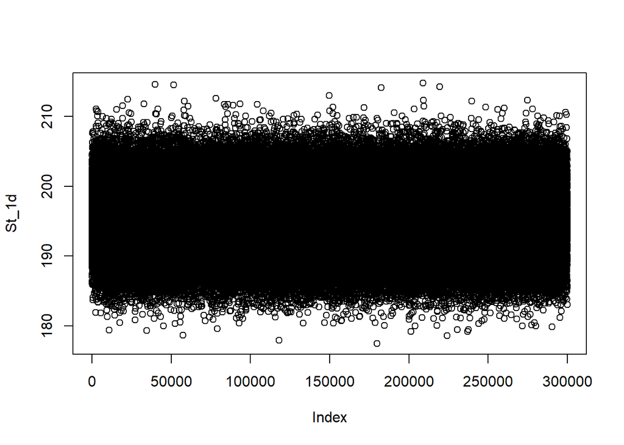

```r
plot(St_1d)
```

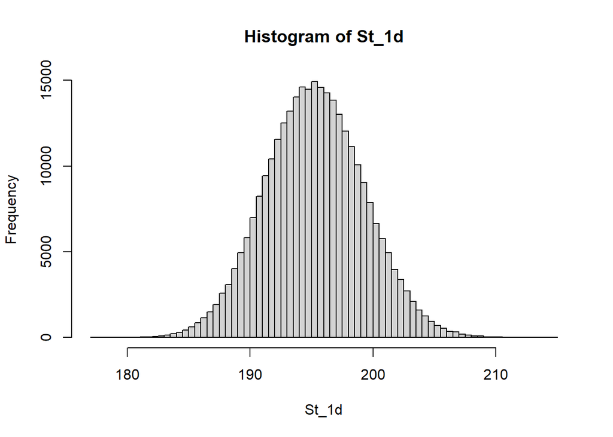

```r
hist(St_1d, n=100)
```

Estimado del precio para 1 día:

```r
mean(St_1d)
```

```
## [1] 195.2638
```

Y antes teníamos:

```r
precio_esp_1d
```

```
## [1] 195.2635
```

Estimado para 1 mes:

```r
dt_1mes <- 20 / dias_cot
St_1m <- So * exp((mu - 0.5 * sigma^2) * dt_1mes + sigma * sqrt(dt_1mes) * Z)
mean(St_1m)
```

```
## [1] 198.0501
```

Estimado para 1 año:

```r
dt_1anio <- 252 / dias_cot
St_1a <- So * exp((mu - 0.5 * sigma^2) * dt_1anio + sigma * sqrt(dt_1anio) * Z)
mean(St_1a)
```

```
## [1] 235.0787
```

# Calcular probabilidades usando el precio que hemos simulado

Probabilidad de que el precio en un día supere los 200 MXN

$$P(S_T > K) \Rightarrow P(S_T > 200) = P(ln(S_T) > ln(200))$$

## Teórica

$$ln(S_T) = ln(S_0) + (\mu - \frac{1}{2}\sigma^2)T + \sigma W_T$$

$$E[ln(S_T)] = ln(S_0) + (\mu - \frac{1}{2}\sigma^2)T$$

$$Desv[ln(S_T)] = \sigma \sqrt{T}$$

$$P(Z > Z_0)$$
Donde:
$$Z_0 = \frac{ln(200) - [ln(S_0) + (\mu - \frac{1}{2}\sigma^2)T)]}{\sigma
\sqrt{T}}$$

```r
e_lnS <- log(So) + (mu - 0.5 * sigma^2) * dt_1d
ds_lnS <- sigma * sqrt(dt_1d)

e_lnS
```

```
## [1] 5.274089
```

```r
ds_lnS
```

```
## [1] 0.02046529
```

```r
z0 <- (log(200) - e_lnS) / ds_lnS
z0
```

```
## [1] 1.183874
```

```r
pnorm(z0, mean=0, sd=1, lower.tail = FALSE ) # lower.tail = FALSE nos da el lado derecho
```

```
## [1] 0.1182314
```

## Empírica

```r
mean(St_1d > 200)
```

```
## [1] 0.1194867
```

Probabilidad de que el precio en un mes disminuya

## Empíricamente

```r
mean(St_1m < So)
```

```
## [1] 0.4539233
```

Ecuación 1 (aproximación):
$$dS_t = S_t\mu d_t + S_t\sigma dW_t$$

$$S_t = S_0 + dS_t$$

Ecuación 2 (exacta):

$$S_t = S_0 e^{(\mu - \frac{1}{2}\sigma^2)T + \sigma W_t}$$

# Efectuar simulaciones para diferentes puntos del tiempo, usando la solución exacta

```r
mean(St_1d)
```

```
## [1] 195.2638
```

```r
mean(St_1a)
```

```
## [1] 235.0787
```

```r
dt_10d <- 10 / dias_cot
St_10d <- So * exp((mu - 0.5 * sigma^2) * dt_10d + sigma * sqrt(dt_10d) * Z)
mean(St_10d)
```

```
## [1] 196.584
```

Para cada uno de estos momentos en el tiempo, debemos obtener el valor esperado, el valor mediano, la moda y un intervalo de confianza digamos al 95%. Todo esto partiendo de lo que conocemos teóricamente.

Para facilitar este cálculo, haremos una función:

Parmámetos: $S_0$, $\mu$, $\sigma$, $T$, $\text{Nivel de confianza}$

```r
gbm_summary <- function(So, mu, sigma, T, nc){
  z_nc = qnorm(1 - (1 - nc) / 2)

  c(
    Precio_Esperado = So * exp(mu * T),
    Mediana = So * exp((mu - 0.5 * sigma^2) * T),
    Moda = So * exp((mu - 1.5 * sigma^2) * T),

    inferior = So * exp(((mu - 0.5 * sigma^2) * T) - z_nc * sigma * sqrt(T)),
    superior = So * exp(((mu - 0.5 * sigma^2) * T) + z_nc * sigma * sqrt(T))
  )
}
```

El resumen del precio para para 1 día:

```r
gbm_summary(So, mu, sigma, dt_1d, 0.95)
```

```
## Precio_Esperado         Mediana            Moda        inferior        superior
##        195.2535        195.2126        195.1308        187.5373        203.2019
```

El resumen del precio para 10 días es:

```r
gbm_summary(So, mu, sigma, dt_10d, 0.95)
```

```
## Precio_Esperado         Mediana            Moda        inferior        superior
##        196.5493        196.1381        195.3183        172.7726        222.6635
```

El resumen del precio para 1 año es:

```r
gbm_summary(So, mu, sigma, dt_1anio, 0.95)
```

```
## Precio_Esperado         Mediana            Moda        inferior        superior
##        234.8088        222.7387        200.4279        117.8313        421.0474
```

Verificar los momentos teóricos del comportamiento del precio, consideremos el caso de 1 año. Definimos 2 momentos, el primero (valor esperado) y el segundo (varianza):

```r
media_teo <- So * exp(mu * 1)
varianza_teo <- So^2 * exp(2 * mu * 1) * (exp(sigma^2 + 1) - 1)

media_emp <- mean(St_1a)
varrianza_emp <- var(St_1a)

rbind(
  Simulado = c(
    Media = media_emp,
    Varianza = varrianza_emp
  ),
  Teórico = c(
    Media = media_teo,
    Varianza = varianza_teo
  )
)
```

```
##             Media   Varianza
## Simulado 235.0787   6188.803
## Teórico  234.8088 111421.024
```

¿Por qué no son iguales?

¿Cómo mejoramos la simulación?

Vamos a construir una trauectoria para un año. Usaremos ambas ideas, aproximación con $d_St$ y la solución exacta:

$$S_{i+1} = S_i e^{(\mu - \frac{1}{2}\sigma^2) T + \sqrt{T} Z_i}$$

```r
z2 <- rnorm(252)
n_dias <- 252
dt <- 1 / n_dias

S_exacta <- numeric(n_dias+1)
S_aprox <- numeric(n_dias+1)

# Para el precio inicial tomamos So
S_exacta[1] <- So
S_aprox[1] <- So


for (i in 1:n_dias) {
  S_exacta[i+1] <- S_exacta[i] * exp((mu - 0.5 * sigma^2) * dt + sigma * sqrt(dt) * z2[i])
  S_aprox[i+1] <- S_aprox[i] + S_aprox[i] * mu * dt + sigma * S_aprox[i] * sqrt(dt) * z2[i]
}
```

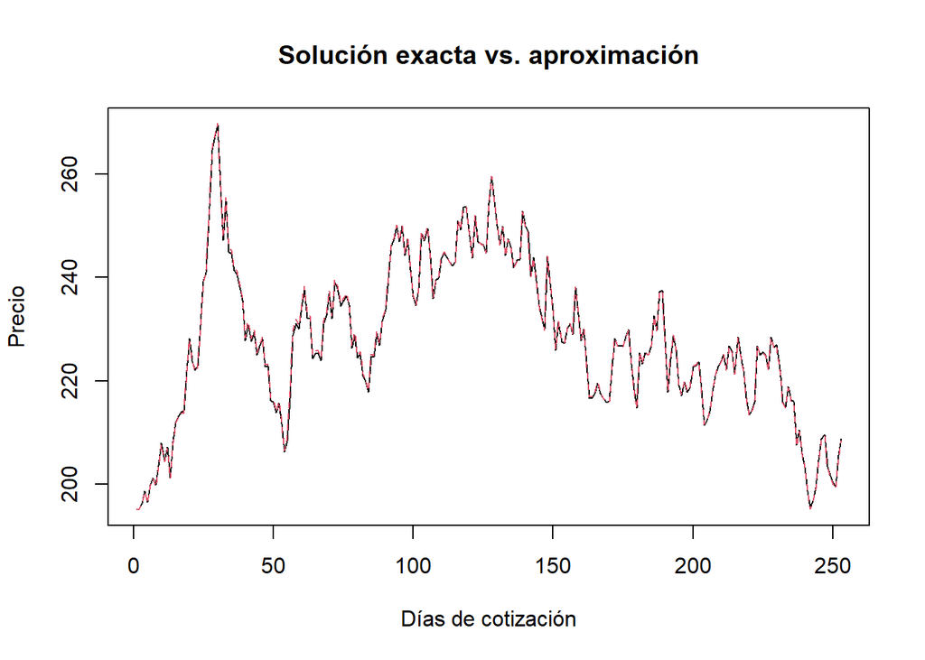

```r
matplot(
  cbind(
    S_aprox, S_exacta
  ),
  type = 'l',
  xlab = 'Días de cotización',
  ylab = 'Precio',
  main = 'Solución exacta vs. aproximación'
)
```